# Pre1_xtl

Xintian Stella Li

2/21/2021

### Chelsea & East Harlem

In the part, we select two neighborhoods to see their bike ridership trends in July 2018 and 2019. The first neighborhood is Chelsea, and the second is East Harlem. Chelsea lies on the west side of Manhattan borough. It is a typical representative of Manhattan, which has a high density built environment, large population, and highly diversed art and culture. East Harlem is more residential, we pick this neighborhood because it may be more similar to other residential boroughs in the NYC.

We use trip data in July from 2018 and 2019 for this part, because that weather in July is most suitable for biking.

Chelsea

East Harlem

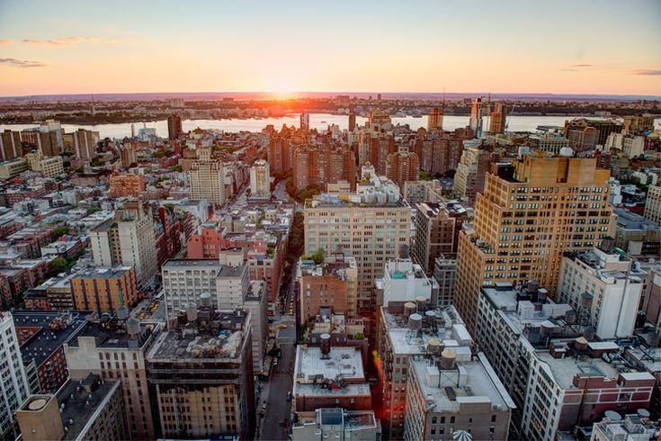

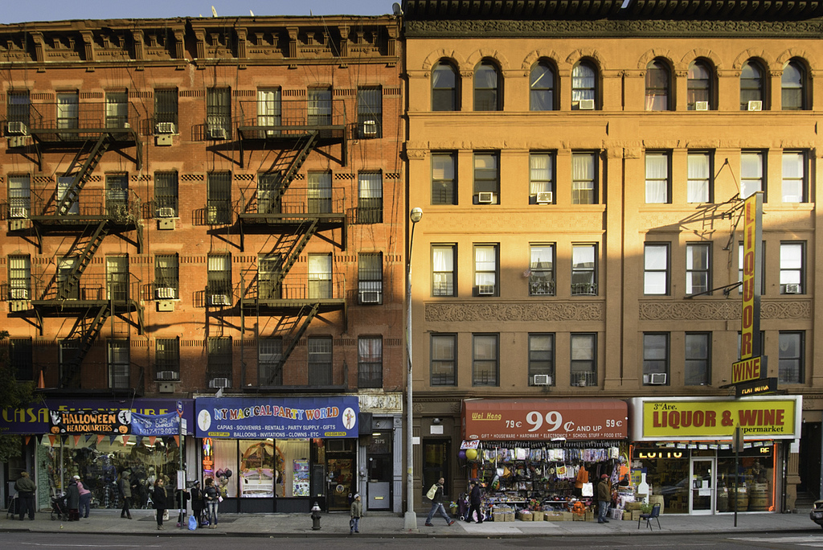

First, Let’s see the ridership trend by hour and by day. As shown in the plots below, ridership in both neighborhood increase from 2018 to 2019. The ridership in Chelsea is much higher than that in East Harlem and the daily peaks are more obvious. The frequency of bike use in a month increase in both neighborhoods.

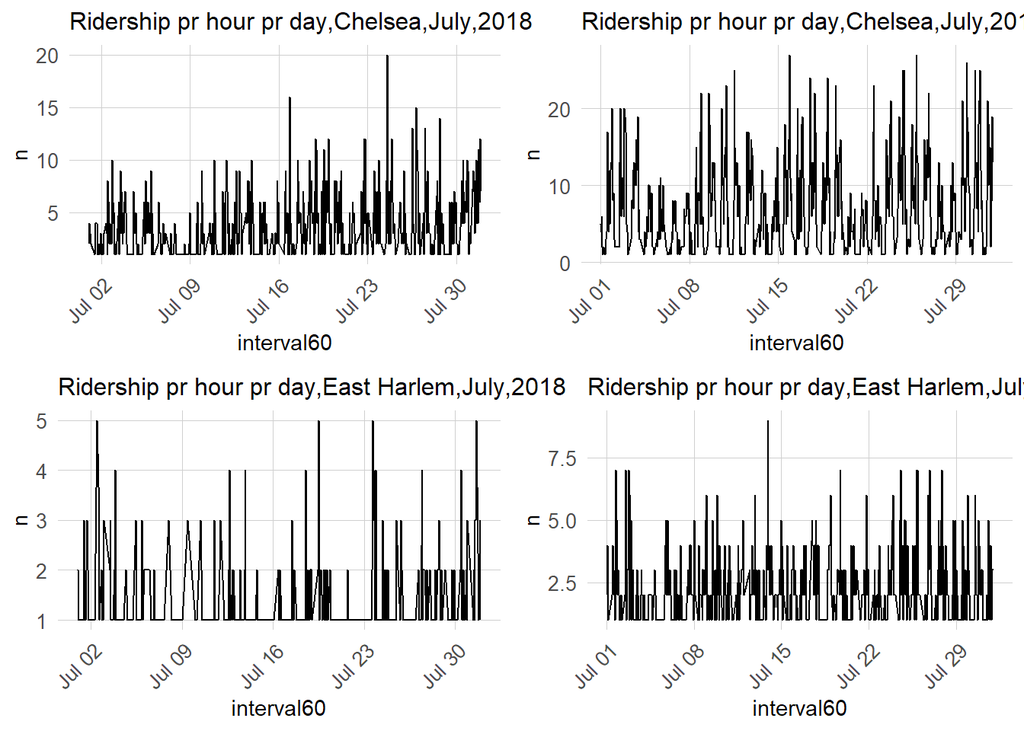

```r
grid.arrange(
  ggplot(chel_07_2018 %>%
           st_drop_geometry() %>%
           mutate(time = ymd_hms(rcrd_tm),
                  interval60 = floor_date(time,unit = "hour")) %>%
           select(-time) %>% group_by(interval60) %>% tally() %>%
           mutate(year = 2018))+geom_line(aes(x=interval60,y=n))+
    labs(title = "Ridership pr hour pr day,Chelsea,July,2018")+plotTheme,
  ggplot(chel_07_2019 %>%
           st_drop_geometry() %>%
           mutate(time = ymd_hms(rcrd_tm),
                  interval60 = floor_date(time,unit = "hour")) %>%
           select(-time) %>% group_by(interval60) %>% tally() %>%
           mutate(year = 2019))+geom_line(aes(x=interval60,y=n))+
    labs(title = "Ridership pr hour pr day,Chelsea,July,2019")+plotTheme,
  ggplot(Har_07_2018 %>%
           st_drop_geometry() %>%
           mutate(time = ymd_hms(rcrd_tm),
                  interval60 = floor_date(time,unit = "hour")) %>%
           select(-time) %>% group_by(interval60) %>% tally() %>%
           mutate(year = 2018))+geom_line(aes(x=interval60,y=n))+
    labs(title = "Ridership pr hour pr day,East Harlem,July,2018")+plotTheme,
  ggplot(Har_07_2019 %>%
           st_drop_geometry() %>%
           mutate(time = ymd_hms(rcrd_tm),
                  interval60 = floor_date(time,unit = "hour")) %>%
           select(-time) %>% group_by(interval60) %>% tally() %>%
           mutate(year = 2019))+geom_line(aes(x=interval60,y=n))+
    labs(title = "Ridership pr hour pr day,East Harlem,July,2019")+plotTheme
)
```

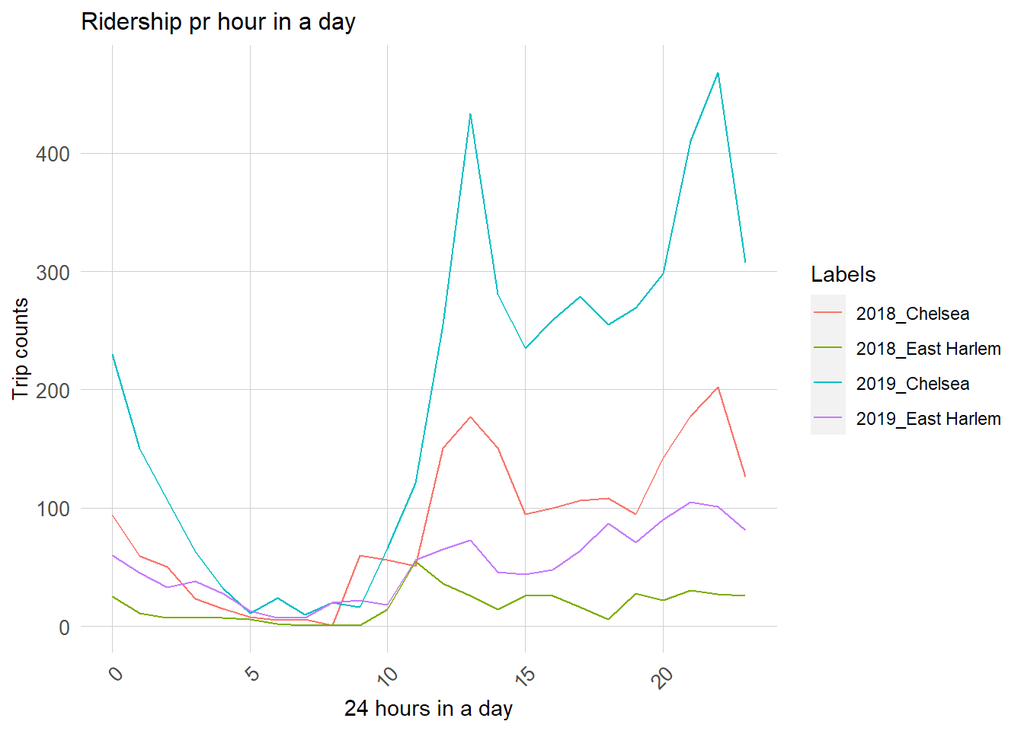

```r
# bike ridership by hour
ggplot(rbind(
  chel_07_2018 %>%
         st_drop_geometry() %>%
         group_by(rhour) %>% tally() %>%
    mutate(year = "2018",
           neighborhood = "Chelsea",
           gr = paste(year,neighborhood,sep = "_")),
  chel_07_2019 %>%
    st_drop_geometry() %>%
    group_by(rhour) %>% tally() %>%
    mutate(year = "2019",
           neighborhood = "Chelsea",
           gr = paste(year,neighborhood,sep = "_")),
  Har_07_2018 %>%
    st_drop_geometry() %>%
    group_by(rhour) %>% tally() %>%
    mutate(year = "2018",
           neighborhood = "East Harlem",
           gr = paste(year,neighborhood,sep = "_")),
  Har_07_2019 %>%
    st_drop_geometry() %>%
    group_by(rhour) %>% tally() %>%
    mutate(year = "2019",
           neighborhood = "East Harlem",
           gr = paste(year,neighborhood,sep = "_"))))+
    geom_line(aes(x=rhour,y = n, group = gr,color = gr,binwidth = 1))+plotTheme+
  labs(title="Ridership pr hour in a day",
       x = "24 hours in a day",
       y ="Trip counts",
       color = "Labels")
```

This plot shows bike ridership by the day of week.The peak bicycle use does not occur on weekends in both neighborhoods.

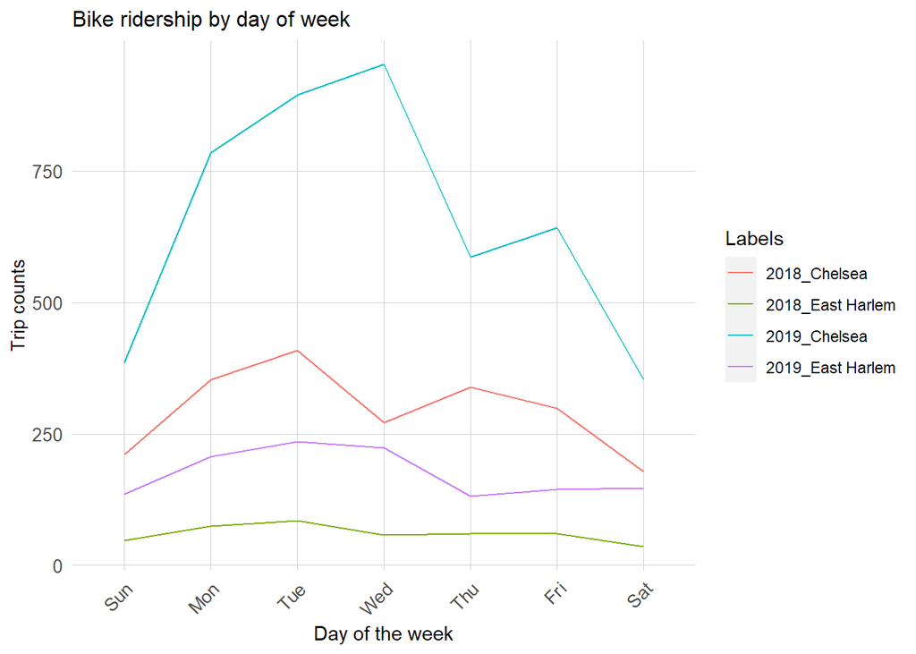

```r
# bike ridership by day of week
ggplot(rbind(
  chel_07_2018 %>%
    st_drop_geometry() %>%
    mutate(dotw = wday(rcrd_tm,label = T)) %>%
    group_by(dotw) %>% tally() %>%
    mutate(year = "2018",
           neighborhood = "Chelsea",
           gr = paste(year,neighborhood,sep = "_")),
  chel_07_2019 %>%
    st_drop_geometry() %>%
    mutate(dotw = wday(rcrd_tm,label = T)) %>%
    group_by(dotw) %>% tally() %>%
    mutate(year = "2019",
           neighborhood = "Chelsea",
           gr = paste(year,neighborhood,sep = "_")),
  Har_07_2018 %>%
    st_drop_geometry() %>%
    mutate(dotw = wday(rcrd_tm,label = T)) %>%
    group_by(dotw) %>% tally() %>%
    mutate(year = "2018",
           neighborhood = "East Harlem",
           gr = paste(year,neighborhood,sep = "_")),
  Har_07_2019 %>%
    st_drop_geometry() %>%
    mutate(dotw = wday(rcrd_tm,label = T)) %>%
    group_by(dotw) %>% tally() %>%
    mutate(year = "2019",
           neighborhood = "East Harlem",
           gr = paste(year,neighborhood,sep = "_"))))+
  geom_line(aes(x=dotw,y = n, group = gr,color = gr))+
  labs(title = "Bike ridership by day of week",
       x = "Day of the week",
       y ="Trip counts",
       color = "Labels")+ plotTheme
```

Next, we study the ridership changes in two boroughs separately.

This graph compares the ridership in Chelsea in two years. As you can see, the increase of ridership mainly happens in the south west part of the neighborhood. For example, the west 22 ST had a monthly ridership of 1020 in 2019. The riverside roads also see an obvious increase between these two years.

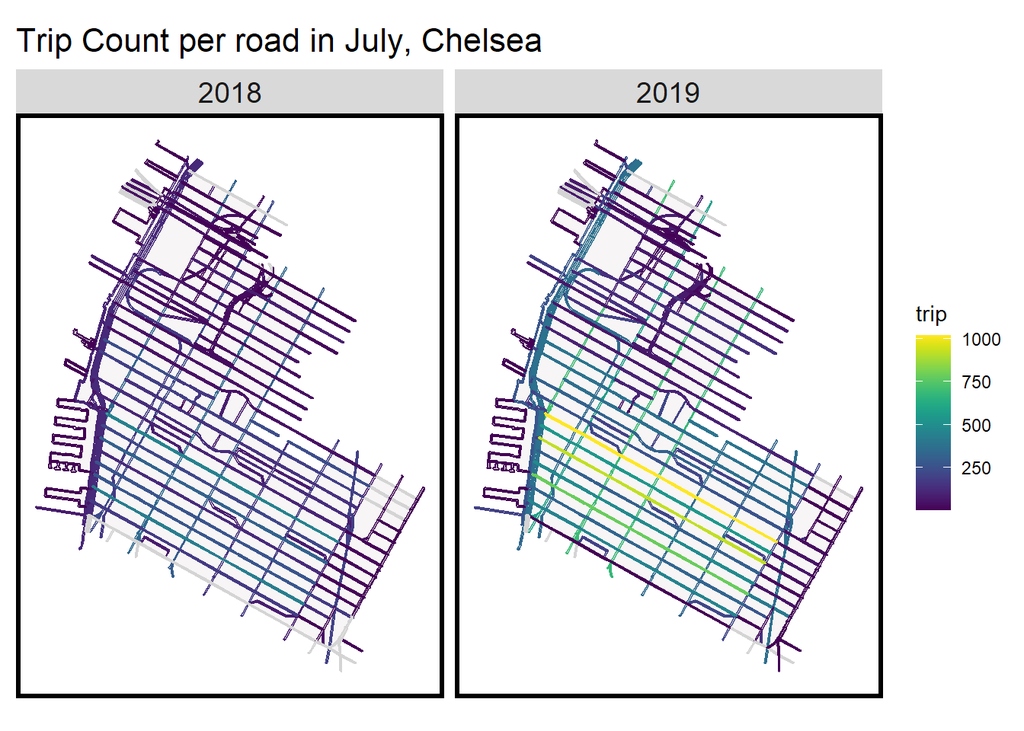

```r
# bike trip in 2018.2019, Chelsea and East Harlem
chel18 <- road15_chel %>%
  select(Street,trip18,geometry) %>%
  mutate(Year = 2018) %>%
  rename(trip=trip18)

chel19 <- road15_chel %>%
  select(Street,trip19,geometry) %>%
  mutate(Year = 2019) %>%
  rename(trip=trip19)

har18 <- road15_har %>%
  select(Street,trip18,geometry) %>%
  mutate(Year = 2018) %>%
  rename(trip=trip18)

har19 <- road15_har %>%
  select(Street,trip19,geometry) %>%
  mutate(Year = 2019) %>%
  rename(trip=trip19)

har_Diff1819 <- road15_har %>%
  select(Street,trip18,trip19,geometry) %>%
  mutate(tripDiff = trip19-trip18) %>%
  select(-trip18,-trip19)

har_Diff1819 <- road15_har %>%
  select(Street,trip18,trip19,geometry) %>%
  mutate(tripDiff = trip19-trip18) %>%
  select(-trip18,-trip19)

har_Diff1819 <- road15_har %>%
  select(Street,trip18,trip19,geometry) %>%
  mutate(tripDiff = trip19-trip18,
         Neighborhood = "East Harlem") %>%
  select(-trip18,-trip19) %>%
  merge(.,newLane_har %>%
          st_drop_geometry(),by.x="Street",by.y="Street_1",all.x=T) %>%
  replace(.,is.na(.),0)

chel_Diff1819 <- road15_chel %>%
  select(Street,trip18,trip19,geometry) %>%
  mutate(tripDiff = trip19-trip18,
         Neighborhood = "Chelsea") %>%
  select(-trip18,-trip19) %>%
  merge(.,newLane_chel %>%
          st_drop_geometry(),by.x="Street",by.y="Street_1",all.x=T) %>%
  replace(.,is.na(.),0)


#Chelsea
ggplot() +
  geom_sf(data = chelsea,fill = "#f7f5f5",col = NA)+
  geom_sf(data = rbind(chel18,chel19),aes(color = trip))+
  scale_color_viridis(direction = 1,
                      discrete = F, option = "viridis",
                      na.value = "#D4D4D4")+
  labs(title = "Trip Count per road in July, Chelsea") + facet_wrap(~Year)+ mapTheme()
```

Then we take a closer look at the bicycle use in Chelsea. This map visualize the difference in ridership between 2018 and 2019. Although most roads see increase from two years. There are some road where the ridership drops in 2019. For instance, the west 16th st, had a drop of 101 ridership in July. The ridership in west 25th and 36th st also dropped.

We also pay attention to the ridership change on newly added bike lanes. As you can see on the right map, the ridership see great increase on both 7th Ave and 9th Ave, which had new bike lanes in 2018.

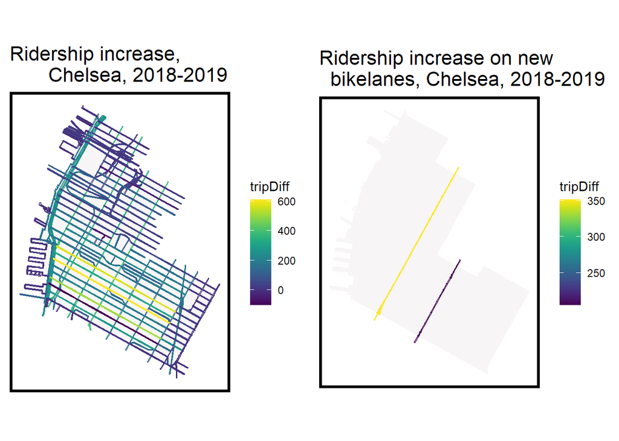

```r
# Diff in two years
grid.arrange(
  ggplot()+
  geom_sf(data = chelsea,fill = "#f7f5f5",col = NA)+
  geom_sf(data = chel_Diff1819,aes(color = tripDiff))+
  scale_color_viridis(direction = 1,
                      discrete = F, option = "viridis",
                      na.value = "#D4D4D4")+
  labs(title = "Ridership increase,
       Chelsea, 2018-2019") +
  mapTheme(),
  ggplot()+
  geom_sf(data = chelsea,fill = "#f7f5f5",col = NA)+
  geom_sf(data = chel_Diff1819[chel_Diff1819$isNew==1,],aes(color = tripDiff))+
  scale_color_viridis(direction = 1,
                      discrete = F, option = "viridis",
                      na.value = "#D4D4D4")+
  labs(title = "Ridership increase on new
  bikelanes, Chelsea, 2018-2019") +
  mapTheme(),
  ncol=2
)
```

In East Harlem, the ridership are more concentrated on several roads. The PARK AVENUE has the highest ridership of 311 in July, 2019. Other connecting roads around park avenue also see increase in bike ridership, however, the increase is relatively small compared with that on Park Avenue.

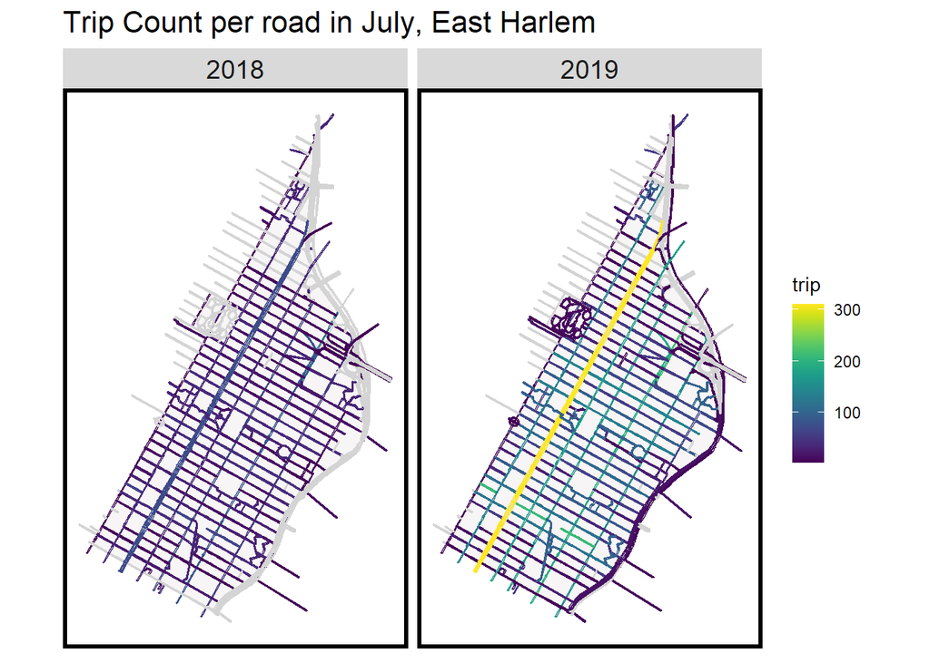

```r
#East Harlem
ggplot() +
  geom_sf(data = eastHarlem,fill = "#f7f5f5",col = NA)+
  geom_sf(data = rbind(har18,har19),aes(color = trip))+
  scale_color_viridis(direction = 1,
                      discrete = F, option = "viridis",
                      na.value = "#D4D4D4")+
  labs(title = "Trip Count per road in July, East Harlem") +
  facet_wrap(~Year)+
  mapTheme()
```

When we see the ridership difference between two years, we can see the increase in ridership also concentrated on Park AVE. There are also some increase on new added bike lanes.

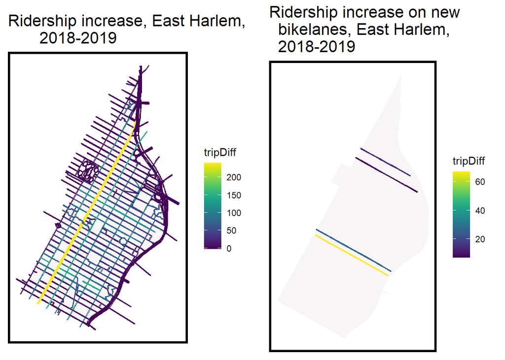

```r
grid.arrange(
  ggplot()+
  geom_sf(data = eastHarlem,fill = "#f7f5f5",col = NA)+
  geom_sf(data = har_Diff1819,aes(color = tripDiff))+
  scale_color_viridis(direction = 1,
                      discrete = F, option = "viridis",
                      na.value = "#D4D4D4")+
  labs(title = "Ridership increase, East Harlem,
       2018-2019") +
  mapTheme(),
  ggplot()+
  geom_sf(data = eastHarlem,fill = "#f7f5f5",col = NA)+
  geom_sf(data = har_Diff1819[har_Diff1819$isNew==1,],aes(color = tripDiff))+
  scale_color_viridis(direction = 1,
                      discrete = F, option = "viridis",
                      na.value = "#D4D4D4")+
  labs(title = "Ridership increase on new
  bikelanes, East Harlem,
  2018-2019") +
  mapTheme(),
  ncol=2
)
```